# Looking Back on 2018

```r
library(data.table)
library(ggplot2)
library(riingo)
library(kableExtra)
library(magrittr)
library(grid)
library(gtable)
library(RplotterPkg)
library(RtsaPkg)
```

Author: Rick Dean

Article date: 2020-12-19

Abstract

The following notes/R scripts were inspired from an article [Looking Back on 2018](http://www.reproduciblefinance.com/2019/01/14/looking-back-on-last-year/) by Jonathan Regenstein.

# Looking Back on 2018

## The data

### Set the Tiingo API key token

```r
riingo::riingo_set_token(RtsaPkg::read_tingo_key())
```

### Get the daily prices

1. Set 10 sector Exchange-Traded Funds (ETF’s i.e. sector indexes) plus the SP500 index (SPY) along with their corresponding sector labels.

```r
symbol_sector_dt <- data.table::data.table(
  Symbol = c("XLY", "XLP", "XLE",
          "XLF", "XLV", "XLI", "XLB",
          "XLK", "XLU", "XLRE",
          "SPY"),
  Sector = c("Consumer Discretionary", "Consumer Staples", "Energy",
          "Financials", "Health Care", "Industrials", "Materials",
          "Information Technology", "Utilities", "Real Estate",
          "Market")
)
```

2. Get the daily prices for 2018 for the symbols:

```r
prices_dt <- RtsaPkg::get_tiingo_stock_prices(symbols = symbol_sector_dt$Symbol, from = "2017-12-29", to = "2018-12-31")
prices_dt <- prices_dt[, .(Symbol, Date, AdjClose)]
str(prices_dt)
```

```
## Classes 'data.table' and 'data.frame':   2772 obs. of  3 variables:
##  $ Symbol  : Factor w/ 11 levels "SPY","XLB","XLE",..: 1 1 1 1 1 1 1 1 1 1 ...
##  $ Date    : Date, format: "2017-12-29" "2018-01-02" ...
##  $ AdjClose: num  252 254 256 257 258 ...
##  - attr(*, ".internal.selfref")=<externalptr>
```

3. Outer join both `ticker_sector_dt` and `prices_dt` using *Symbol* as the key:

```r
data.table::setkey(symbol_sector_dt, "Symbol")
data.table::setkey(prices_dt, "Symbol")
prices_dt <- prices_dt[symbol_sector_dt]
prices_dt[, Sector := as.factor(Sector)]
prices_dt[1:10]
```

```
##     Symbol       Date AdjClose Sector
##  1:    SPY 2017-12-29 252.1909 Market
##  2:    SPY 2018-01-02 253.9959 Market
##  3:    SPY 2018-01-03 255.6024 Market
##  4:    SPY 2018-01-04 256.6798 Market
##  5:    SPY 2018-01-05 258.3903 Market
##  6:    SPY 2018-01-08 258.8628 Market
##  7:    SPY 2018-01-09 259.4487 Market
##  8:    SPY 2018-01-10 259.0518 Market
##  9:    SPY 2018-01-11 260.9419 Market
## 10:    SPY 2018-01-12 262.6429 Market
```

## Group by sector and show the first index

```r
first_index_dt <- prices_dt[, .SD[1], by = Sector]
```

```r
first_index_dt %>%
kbl(
  format = "html",
  caption = "First Prices Across Sectors",
  align = c("c", "c", "c", "c"),
  digits = 1) %>%
kable_paper(full_width = T, position = "center") %>%
row_spec(0, background = "purple", color = "white, font_size = 22")
```

First Prices Across Sectors

| Sector | Symbol | Date | AdjClose |
| --- | --- | --- | --- |
| Market | SPY | 2017-12-29 | 252.2 |
| Materials | XLB | 2017-12-29 | 57.1 |
| Energy | XLE | 2017-12-29 | 62.3 |
| Financials | XLF | 2017-12-29 | 26.3 |
| Industrials | XLI | 2017-12-29 | 71.5 |
| Information Technology | XLK | 2017-12-29 | 61.6 |
| Consumer Staples | XLP | 2017-12-29 | 52.7 |
| Real Estate | XLRE | 2017-12-29 | 30.1 |
| Utilities | XLU | 2017-12-29 | 48.1 |
| Health Care | XLV | 2017-12-29 | 78.5 |
| Consumer Discretionary | XLY | 2017-12-29 | 95.3 |

Note: All showing the starting date of 2017-12-29

## Group by Sector and compute the daily return

The “DailyReturn” column is the log10 difference between the current adjusted value and its prior daily adjusted value.

```r
prices_daily_return_dt <- prices_dt[, DailyReturn := log10(AdjClose) - log10(shift(AdjClose, 1)), by = Sector]
prices_daily_return_dt <- na.omit(prices_dt, cols = "DailyReturn")
str(prices_daily_return_dt)
```

```
## Classes 'data.table' and 'data.frame':   2761 obs. of  5 variables:
##  $ Symbol     : chr  "SPY" "SPY" "SPY" "SPY" ...
##  $ Date       : Date, format: "2018-01-02" "2018-01-03" ...
##  $ AdjClose   : num  254 256 257 258 259 ...
##  $ Sector     : Factor w/ 11 levels "Consumer Discretionary",..: 8 8 8 8 8 8 8 8 8 8 ...
##  $ DailyReturn: num  0.003097 0.002738 0.001827 0.002885 0.000793 ...
##  - attr(*, "sorted")= chr "Symbol"
##  - attr(*, ".internal.selfref")=<externalptr>
```

Note: the use of *shift()* and that the number of observations goes from 2772 to 2761 (11 sector observations from 2017-12-29 were lost from computing the first shift). Also our dates are starting at “2018-01-02”.

### Tabulate the first row of each sector group (2018-01-02)

```r
prices_daily_return_dt[, .SD[1], by = Sector] %>%
  kbl(
  format = "html",
  caption = "First DailyReturn Across Sectors",
  align = c("c", "c", "c", "c", "c")) %>%
kable_paper(full_width = T, position = "center") %>%
row_spec(0, background = "purple", color = "white, font_size = 22")
```

First DailyReturn Across Sectors

| Sector | Symbol | Date | AdjClose | DailyReturn |
| --- | --- | --- | --- | --- |
| Market | SPY | 2018-01-02 | 253.99588 | 0.0030973 |
| Materials | XLB | 2018-01-02 | 57.93652 | 0.0061270 |
| Energy | XLE | 2018-01-02 | 63.31334 | 0.0070938 |
| Financials | XLF | 2018-01-02 | 26.29259 | 0.0001556 |
| Industrials | XLI | 2018-01-02 | 71.97531 | 0.0025750 |
| Information Technology | XLK | 2018-01-02 | 62.33724 | 0.0053321 |
| Consumer Staples | XLP | 2018-01-02 | 52.39485 | -0.0026801 |
| Real Estate | XLRE | 2018-01-02 | 29.94314 | -0.0025123 |
| Utilities | XLU | 2018-01-02 | 47.60503 | -0.0040585 |
| Health Care | XLV | 2018-01-02 | 79.39389 | 0.0048578 |
| Consumer Discretionary | XLY | 2018-01-02 | 96.71209 | 0.0065512 |

### Tabulate the second row of each sector group (2018-01-03)

```r
prices_daily_return_dt[, .SD[2], by = Sector] %>%
  kbl(
  format = "html",
  caption = "Second DailyReturn Across Sectors",
  align = c("c", "c", "c", "c", "c")) %>%
kable_paper(full_width = T, position = "center") %>%
row_spec(0, background = "purple", color = "white, font_size = 22")
```

Second DailyReturn Across Sectors

| Sector | Symbol | Date | AdjClose | DailyReturn |
| --- | --- | --- | --- | --- |
| Market | SPY | 2018-01-03 | 255.60243 | 0.0027383 |
| Materials | XLB | 2018-01-03 | 58.34233 | 0.0030314 |
| Energy | XLE | 2018-01-03 | 64.26153 | 0.0064558 |
| Financials | XLF | 2018-01-03 | 26.43385 | 0.0023270 |
| Industrials | XLI | 2018-01-03 | 72.36299 | 0.0023329 |
| Information Technology | XLK | 2018-01-03 | 62.85720 | 0.0036075 |
| Consumer Staples | XLP | 2018-01-03 | 52.37632 | -0.0001537 |
| Real Estate | XLRE | 2018-01-03 | 29.95228 | 0.0001326 |
| Utilities | XLU | 2018-01-03 | 47.23105 | -0.0034253 |
| Health Care | XLV | 2018-01-03 | 80.15355 | 0.0041357 |
| Consumer Discretionary | XLY | 2018-01-03 | 97.15612 | 0.0019894 |

## Plot the *DailyReturn* across time for each sector group

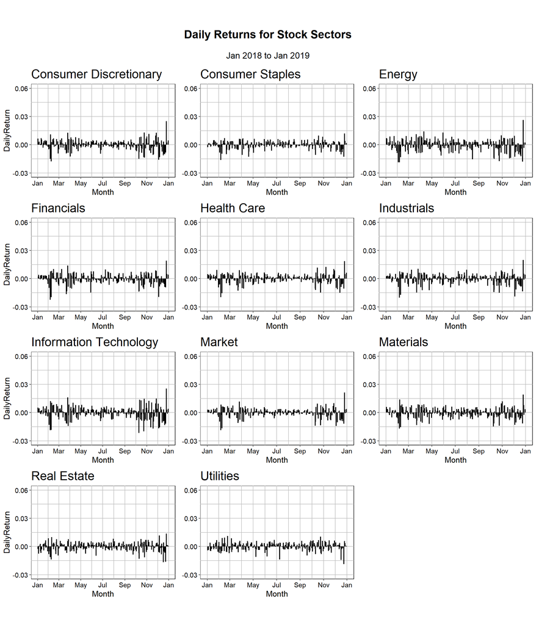

```r
RplotterPkg::multi_stick_plot(
  df = prices_daily_return_dt,
  factor_var = "Sector",
  factor_x = "Date",
  aes_y = "DailyReturn",
  title = "Daily Returns for Stock Sectors",
  subtitle = "Jan 2018 to Jan 2019",
  x_title = "Month",
  columns = 3,
  rot_y_tic_label = T,
  x_limits = as.Date(c("2018-01-01", "2019-01-01")),
  x_major_breaks = seq(as.Date("2018-01-01"), as.Date("2019-01-01"), by="2 month"),
  x_date_labels = "%b",
  y_limits = c(-0.03, 0.06),
  y_major_breaks = seq(-0.03, 0.06, 0.03),
  row_height = 3.0
)
```

1. Create two numeric variables *ReturnPos* and *ReturnNeg*:

```r
prices_pos_neg_dt <- prices_daily_return_dt[, .(Sector, Date, ReturnPos = ifelse(DailyReturn > 0, DailyReturn, 0.0), ReturnNeg = ifelse(DailyReturn < 0, DailyReturn, 0.0))]
str(prices_pos_neg_dt)
```

```
## Classes 'data.table' and 'data.frame':   2761 obs. of  4 variables:
##  $ Sector   : Factor w/ 11 levels "Consumer Discretionary",..: 8 8 8 8 8 8 8 8 8 8 ...
##  $ Date     : Date, format: "2018-01-02" "2018-01-03" ...
##  $ ReturnPos: num  0.003097 0.002738 0.001827 0.002885 0.000793 ...
##  $ ReturnNeg: num  0 0 0 0 0 ...
##  - attr(*, ".internal.selfref")=<externalptr>
```

2. Create a long dataframe involving variables “return_pos” and “return_neg”.

```r
pos_neg_long_dt <- data.table::melt(prices_pos_neg_dt,
                                    id.vars = c("Sector","Date"),
                                    measure.vars = c("ReturnPos", "ReturnNeg"),
                                    variable.name = "Direction", value.name = "DailyReturn")
str(pos_neg_long_dt)
```

```
## Classes 'data.table' and 'data.frame':   5522 obs. of  4 variables:
##  $ Sector     : Factor w/ 11 levels "Consumer Discretionary",..: 8 8 8 8 8 8 8 8 8 8 ...
##  $ Date       : Date, format: "2018-01-02" "2018-01-03" ...
##  $ Direction  : Factor w/ 2 levels "ReturnPos","ReturnNeg": 1 1 1 1 1 1 1 1 1 1 ...
##  $ DailyReturn: num  0.003097 0.002738 0.001827 0.002885 0.000793 ...
##  - attr(*, ".internal.selfref")=<externalptr>
```

3. Plot the two directions across sectors:

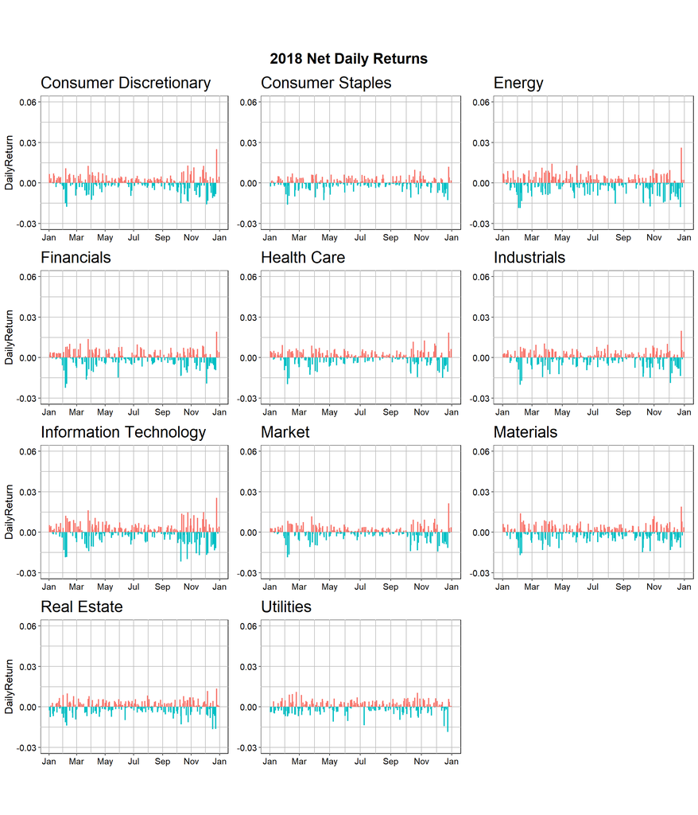

```r
RplotterPkg::multi_stick_plot(
  df = pos_neg_long_dt,
  factor_var = "Sector",
  factor_x = "Date",
  title = "2018 Net Daily Returns",
  columns = 3,
  aes_y = "DailyReturn",
  aes_color = "Direction",
  rot_y_tic_label = T,
  x_limits = as.Date(c("2018-01-01", "2019-01-01")),
  x_major_breaks = seq(as.Date("2018-01-01"), as.Date("2019-01-01"), by="2 month"),
  x_date_labels = "%b",
  y_limits = c(-0.03, 0.06),
  y_major_breaks = seq(-0.03, 0.06, 0.03),
  row_height = 3.0,
  show_legend = F
)
```

## Plot Information Technology

1. Filter out “Information Technology”:

```r
info_tech_dt <- pos_neg_long_dt[Sector == "Information Technology"]
```

2. Plot the positive and negative:

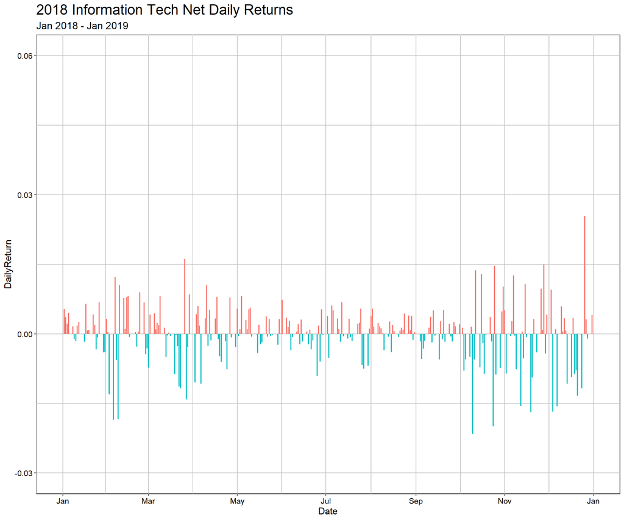

```r
RplotterPkg::create_stick_plot(
  df = info_tech_dt,
  aes_x = "Date",
  aes_y = "DailyReturn",
  aes_color = "Direction",
  title = "2018 Information Tech Net Daily Returns",
  subtitle = "Jan 2018 - Jan 2019",
  rot_y_tic_label = T,
  x_limits = as.Date(c("2018-01-01", "2019-01-01")),
  x_major_breaks = seq(as.Date("2018-01-01"), as.Date("2019-01-01"), by="2 month"),
  x_date_labels = "%b",
  y_limits = c(-0.03, 0.06),
  y_major_breaks = seq(-0.03, 0.06, 0.03),
  show_legend = F
)
```